# 16. Time Series Data and Window Functions

## French COVID-19

### Load the Data

We will be using the same data sets from the previous notebook:

```r
dept <- read_sf(file.path("..", "data", "france_departement.geojson"))
pop <- read_csv(file.path("..", "data", "france_departement_population.csv"))
covid <- read_csv(file.path("..", "data", "france_departement_covid.csv"))
```

This time, we will look into the temporal components of the data and see how they can be integrated into the spatial visualisations.

### Plotting Dates

Notice that the date variable in the `covid` dataset has a special data type called “date”. One some reflection, it seems reasonable to have a seperate data type for dates because they act somewhat like a number (ordered, some meaning of distances) and somewhat like a categorical variable (fixed values). In this section we will explore how to work with these data objects.

```r
covid
```

```
## # A tibble: 19,998 × 9
##    date       departement departem…¹ decea…² hospi…³ reani…⁴ recov…⁵ hospi…⁶
##    <date>     <chr>       <chr>        <dbl>   <dbl>   <dbl>   <dbl>   <dbl>
##  1 2020-03-18 01          Ain              0       2       0       1      NA
##  2 2020-03-18 02          Aisne            9       0       0       0      NA
##  3 2020-03-18 03          Allier           0       0       0       0      NA
##  4 2020-03-18 04          Alpes-de-…       0       3       1       2      NA
##  5 2020-03-18 05          Hautes-Al…       0       8       1       9      NA
##  6 2020-03-18 06          Alpes-Mar…       2      25       1      47      NA
##  7 2020-03-18 07          Ardèche          0       0       0       0      NA
##  8 2020-03-18 08          Ardennes         0       0       0       1      NA
##  9 2020-03-18 09          Ariège           0       1       1       2      NA
## 10 2020-03-18 10          Aube             0       5       0       0      NA
## # … with 19,988 more rows, 1 more variable: reanimation_new <dbl>, and
## #   abbreviated variable names ¹departement_name, ²deceased, ³hospitalised,
## #   ⁴reanimation, ⁵recovered, ⁶hospitalised_new
```

We have already worked a bit for date objects in plotting. When used as the x-axis (or less commonly, y-axis), a date object will display okay with no additional work on our part.

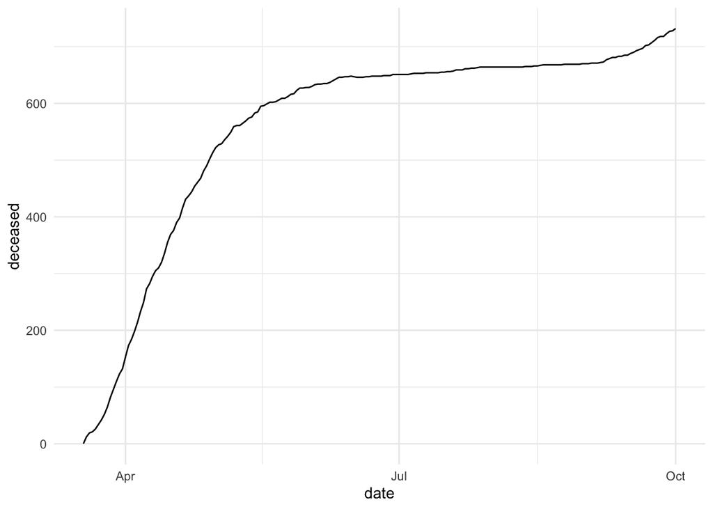

```r
covid %>%
  filter(departement == 69) %>%
  ggplot(aes(date, deceased)) +
    geom_line()
```

Often with dates, it is useful to manually modify the labels on the time-based axis. We do this with `scale_x_date` (or its y-equivalent if time is on the y-axis). Adding this scale to a plot on its own will have no effect, but we can change the default by changing three parameters:

- `date_breaks` a string describing the frequency of the labels, such as “month” or “2 years”
- `date_minor_breaks` a string describing the frequency of the grid-lines
- `date_labels` format string: [strptime](https://rdrr.io/r/base/strptime.html)

You can set just a subset of these, depending on how much control you want over the plot. For example, let’s label the previous plot by showing a label for every month, and using the pattern “%B” to show (just) the full month’s name.

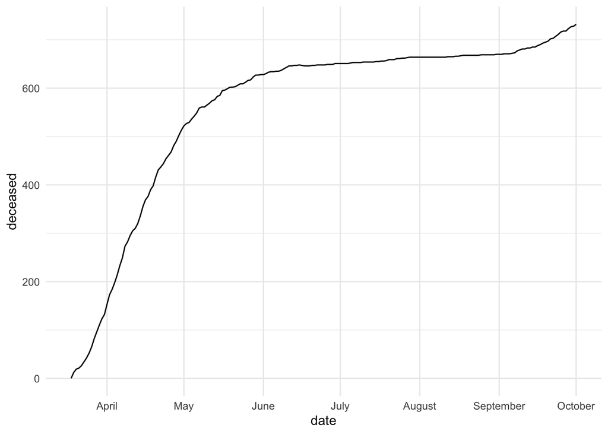

```r
covid %>%
  filter(departement == 69) %>%
  ggplot(aes(date, deceased)) +
    geom_line() +
    scale_x_date(date_breaks = "month", date_labels = "%B", date_minor_breaks = "month")
```

The R programming language is designed to be used in English, but often the output of plots will be distributed in other languages. You will note in the previous plot that the month names are in English. How do we change this? We can change the *locale* used within R by using the `Sys.setlocale` function. This data comes from France, so let’s change our locale to French:

```r
Sys.setlocale(locale = "fr_FR.UTF-8") # macOS
```

```
## [1] "fr_FR.UTF-8/fr_FR.UTF-8/fr_FR.UTF-8/C/fr_FR.UTF-8/en_US.UTF-8"
```

```r
# Sys.setlocale(locale = "French_France.1252") # Windows
```

Running the plot again shows the month names in French:

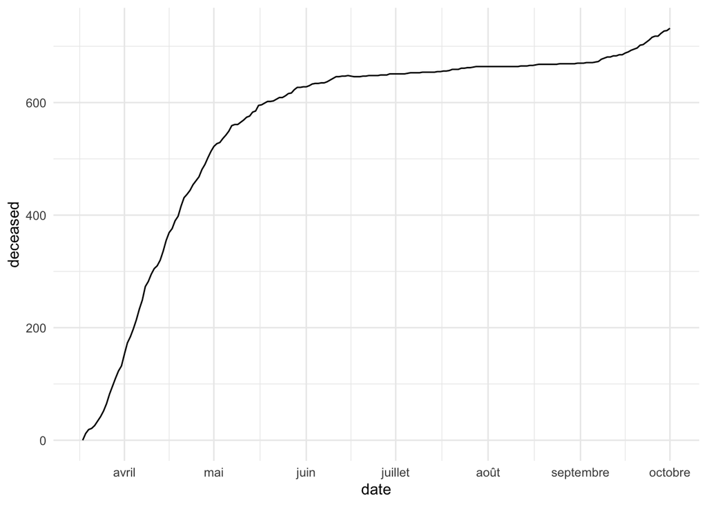

```r
covid %>%
  filter(departement == 69) %>%
  ggplot(aes(date, deceased)) +
    geom_line() +
    scale_x_date(date_breaks = "month", date_labels = "%B")
```

For the rest of the notebook, we will move back to English:

```r
Sys.setlocale(locale = "en_US.UTF-8")
```

```
## [1] "en_US.UTF-8/en_US.UTF-8/en_US.UTF-8/C/en_US.UTF-8/en_US.UTF-8"
```

You will note that I actually included this line the header of the notebook for today in order to make sure that the notebook is running in an English/US locale. On your personal machine this may be different.

### Working with date variables

There are a number of functions that allow us to manipulate date objects, most frequently to extract a particular element of the date and save it as a new variable within a call to `mutate`. For example, `year()`, `month()` and `day()` return a numeric version of the corresponding date components:

```r
covid %>%
  mutate(year = year(date), month = month(date), day = day(date)) %>%
  select(date, year, month, day) %>%
  unique()
```

```
## # A tibble: 198 × 4
##    date        year month   day
##    <date>     <dbl> <dbl> <int>
##  1 2020-03-18  2020     3    18
##  2 2020-03-19  2020     3    19
##  3 2020-03-20  2020     3    20
##  4 2020-03-21  2020     3    21
##  5 2020-03-22  2020     3    22
##  6 2020-03-23  2020     3    23
##  7 2020-03-24  2020     3    24
##  8 2020-03-25  2020     3    25
##  9 2020-03-26  2020     3    26
## 10 2020-03-27  2020     3    27
## # … with 188 more rows
```

We can also do mathematical operations on dates; adding or subtracting an integer changes the date by the specified amount of days:

```r
covid %>%
  mutate(date_next = date + 2) %>%
  select(date, date_next) %>%
  unique()
```

```
## # A tibble: 198 × 2
##    date       date_next
##    <date>     <date>
##  1 2020-03-18 2020-03-20
##  2 2020-03-19 2020-03-21
##  3 2020-03-20 2020-03-22
##  4 2020-03-21 2020-03-23
##  5 2020-03-22 2020-03-24
##  6 2020-03-23 2020-03-25
##  7 2020-03-24 2020-03-26
##  8 2020-03-25 2020-03-27
##  9 2020-03-26 2020-03-28
## 10 2020-03-27 2020-03-29
## # … with 188 more rows
```

It can also be useful to create a temporary date object, for example to select a subset of days. This is done with one of two functions, the `ymd` function, which takes a single string formatted as “YYYY-MM-DD”:

```r
covid %>%
  filter(between(date, ymd("2020-07-02"), ymd("2020-07-07"))) %>%
  select(date) %>%
  unique()
```

```
## # A tibble: 6 × 1
##   date
##   <date>
## 1 2020-07-02
## 2 2020-07-03
## 3 2020-07-04
## 4 2020-07-05
## 5 2020-07-06
## 6 2020-07-07
```

Or the `make_date` function, which takes seperate numeric arguments for the year, month, and date. Note that the year, month, and day default to 1970, 1, and 1, respectively.

```r
covid %>%
  filter(between(date, make_date(2020, 07), make_date(2020, 07, 15))) %>%
  select(date) %>%
  unique()
```

```
## # A tibble: 15 × 1
##    date
##    <date>
##  1 2020-07-01
##  2 2020-07-02
##  3 2020-07-03
##  4 2020-07-04
##  5 2020-07-05
##  6 2020-07-06
##  7 2020-07-07
##  8 2020-07-08
##  9 2020-07-09
## 10 2020-07-10
## 11 2020-07-11
## 12 2020-07-12
## 13 2020-07-13
## 14 2020-07-14
## 15 2020-07-15
```

The functions `make_date` and `ymd` can also be used within a mutate function to create a date object when it is not automatically constructed.

Another useful function is `isoweek`, which returns a numeric description of the week of the year.

```r
covid %>%
  mutate(week = isoweek(date)) %>%
  select(date, week) %>%
  unique()
```

```
## # A tibble: 198 × 2
##    date        week
##    <date>     <dbl>
##  1 2020-03-18    12
##  2 2020-03-19    12
##  3 2020-03-20    12
##  4 2020-03-21    12
##  5 2020-03-22    12
##  6 2020-03-23    13
##  7 2020-03-24    13
##  8 2020-03-25    13
##  9 2020-03-26    13
## 10 2020-03-27    13
## # … with 188 more rows
```

And `wday` returns the day of the week. Setting the options `label = TRUE` and `abbr = FALSE` returns these as an ordered factor:

```r
covid %>%
  mutate(wday = wday(date, label = TRUE, abbr = FALSE)) %>%
  select(date, wday) %>%
  unique()
```

```
## # A tibble: 198 × 2
##    date       wday
##    <date>     <ord>
##  1 2020-03-18 Wednesday
##  2 2020-03-19 Thursday
##  3 2020-03-20 Friday
##  4 2020-03-21 Saturday
##  5 2020-03-22 Sunday
##  6 2020-03-23 Monday
##  7 2020-03-24 Tuesday
##  8 2020-03-25 Wednesday
##  9 2020-03-26 Thursday
## 10 2020-03-27 Friday
## # … with 188 more rows
```

Note that the same options (label and abbr) also exist for the `month()` function. Also, we can set the locale of `wday` within the function itself like this:

```r
covid %>%
  mutate(wday = wday(date, locale = "fr_FR.UTF-8", label = TRUE, abbr = FALSE)) %>%
  select(date, wday) %>%
  unique()
```

```
## # A tibble: 198 × 2
##    date       wday
##    <date>     <ord>
##  1 2020-03-18 Mercredi
##  2 2020-03-19 Jeudi
##  3 2020-03-20 Vendredi
##  4 2020-03-21 Samedi
##  5 2020-03-22 Dimanche
##  6 2020-03-23 Lundi
##  7 2020-03-24 Mardi
##  8 2020-03-25 Mercredi
##  9 2020-03-26 Jeudi
## 10 2020-03-27 Vendredi
## # … with 188 more rows
```

Otherwise, it uses the setting from `Sys.setlocale`. Note that setting the option inside the function does not change the locale for subsequent plots or functions.